# Développement web dlm3

## Responsive Web Design

### *Conception de sites web adaptatifs*

# Site adaptatif ?

- Surfer depuis : PC, mobiles, tablettes, tv, …
- UX : navigation avec un minimum de zoom, pan, scroll
- S’adapter aux spécifités des appareils
  - orientation
  - taille caractères
  - modes d’interaction (ex: tactile, hover, …)
  - …
- 1 seul site à gérer : m.cool.com ni de cool.com/mobile
- Le même contenu pour tous
- Souvent basé sur la largeur de l’écran
- CSS3
- *Responsive Web Design* (1), [Exemple](http://alistapart.com/d/responsive-web-design/ex/ex-site-FINAL.html)

# Techniques

- Media queries : Taille de l’écran (ou sortie)
- UNITES RELATIVES
- Fonts : Dimensions en em
- Fluid Grids : Disposition et taille des éléments en %
- Flexible images (and media) : Taille des médias en %
- Autres considérations
  - Adaptatif avec [grilles fixes](http://www.jonikorpi.com/frameless/)
  - [Performances](https://browserdiet.com/) : tps chargement, requêtes inutiles, …
  - Transitions CSS
  - …
- [Exemple](http://webdesignerwall.com/tutorials/responsive-design-in-3-steps)

# [Media Queries](https://developer.mozilla.org/fr/docs/CSS/Media_queries)

- media type : `all, screen, print, tv, braille, handheld, ...`

```html
<link rel="stylesheet" type="text/css" href="style.css" media="screen" />
<link rel="stylesheet" type="text/css" href="printfriendly.css" media="print" />
```

- media query
  1. dans élément link

  ```html
  <link rel="stylesheet" type="text/css" media="screen and (max-device-width: 800px)"
  href="style800.css" />
  ```

  2. dans une feuille de style

  ```css
      #nav {float: right;}
              #nav ul {list-style: none;}
          @media screen and (min-width: 400px) and (orientation: portrait)
              {
                      #nav li {float: right; margin: 0 0 0 .5em; border:1px solid #000000;}
              }
          @media screen and (min-width: 800px)
              {
                  #nav { width: 200px; }
                     #nav li {float: left; margin: 0 0 0 .5em; border: none;}
              }
  ```

  3. Règle CSS import

  ```css
      @import url(style600min.css) screen and (min-width: 600px);
  ```

# [Media Queries](https://developer.mozilla.org/fr/docs/CSS/Media_queries)

```html
    width, height, device-width, device-height, orientation, aspect-ratio,
    device-aspect-ratio, color, color-index, monochrome, resolution, scan, grid
```

- Règles CSS selon medium (souvent min-, max-width)
- Opérateurs : only, not, and
- Au moins 3 layouts : mobile, tablet, desktop
- Resolution breakpoints : 320, 480, 600, 768, 1024, 1200px
- Souvent ces règles sont utilisées pour :
  - agrandir la taille du texte
  - agrandir la taille des zones cliquables (utilisation au doigt)
  - faire passer le contenu sur une seule colonne
  - masquer ou afficher des éléments spécifiques
  - ajuster les dimensions et marges
- Attention à l’ordre de chargement

# Meta Tag [viewport](http://blog.javierusobiaga.com/stop-using-the-viewport-tag-until-you-know-ho)

- Introduit pour [iPhone](https://developer.apple.com/library/content/documentation/AppleApplications/Reference/SafariWebContent/UsingtheViewport/UsingtheViewport.html), puis standard de fait
  - Par défaut, l’affichage est réduit (980px affichés sur écran 320px)
  - Meta tag viewport permet de changer ce ratio
- viewport : display area ≠ rendering surface
- Mobiles : viewport > écran (iphone 3 : v:980 / é:320)
- Media queries comparent au viewport
- Mise à jour du viewport à la taille de l’écran nécessaire :

```html
<meta name="viewport" content="width=device-width; initial-scale=1.0">
```

# Résultat = Cible / Contexte

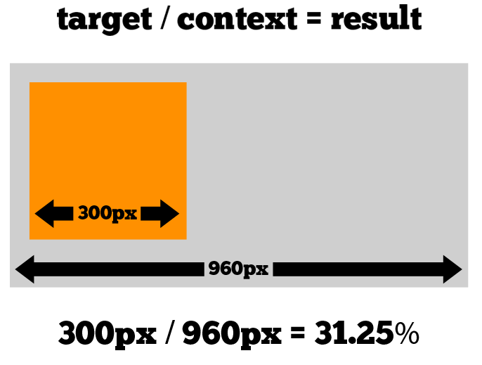

Target / Context

# Texte

- Texte redimensionnable : em pour les polices
- `1rem : font-size:100%` dans élément html (16px/défaut)
- `1em : font-size:100%` dans élément courant
- Conversion px -> em : `result = target/context`
  - ne pas arrondir
  - laisser le rapport en commentaire

# Fluid Grids

- Layout basé sur une grille en pixel
- Conversion px -> % : **result = target/context**
  - ne pas arrondir
  - laisser le rapport en commentaire
- Appliqué au style des divs :

```html
width, margin, padding, background-position, ...
```

# Responsive Images

- Nouveautés de HTML 5
  - Eléments `<picture>`, `<source>`
  - Attributs `srcset` et `sizes`
- [Besoins](http://www.smashingmagazine.com/2014/05/14/responsive-images-done-right-guide-picture-srcset/)
  - Écrans haute densité : `srcset`
  - Taille variable : `srcset` et `sizes`
  - [Substitution](http://ericportis.com/etc/smashing-mag-picture-examples/art-direction.html) et modification layout : `<picture>, <source>`
  - Choix formats de fichiers `<picture>`
- [Différences](https://css-tricks.com/responsive-images-youre-just-changing-resolutions-use-srcset/) entre `<picture>` et `srcset`
- [Exemple](http://www.hteumeuleu.fr/attribut-srcset-images-responsive/) en français

# Flexible images

- Eviter qu’une image ne déborde de son conteneur
  - La réduire

  ```html
  img, embed, object, video{ max-width: 100%; }
  ```

  - La découper

  ```html
    .feature { overflow: hidden; }
    .feature img { display: block; max-width: auto; }
  ```

- Pas de standard pour servir différentes tailles de fichier
- Quelques idées recensées par *Smashing Magazine* (2)

# Outils

- Tester
  - Simulateur mobile des devtools, largeur browser
  - bookmarklet pour afficher les media queries
  - mais surtout tester sur mobile
- Et Après ? [MOBILE FIRST](http://www.lukew.com/resources/mobile_first.asp), [OFFLINE FIRST](http://offlinefirst.org/), [PWA](https://developers.google.com/web/progressive-web-apps/)
- framework ou from scratch ?

# Références

- Exemples
  - [Site](http://responsivewebdesign.com/robot/) support du [livre](https://abookapart.com/products/responsive-web-design) d’Ethan Marcotte
  - [mediaqueri.es](http://mediaqueri.es/)
  - [thenextweb](http://thenextweb.com/dd/2013/01/13/30-new-inspiring-responsive-design-websites/)
  - [designshack](https://designshack.net/articles/css/20-amazing-examples-of-using-media-queries-for-responsive-web-design/)
- Plus loin…
  - [Généralités](http://johnpolacek.github.io/scrolldeck.js/decks/responsive/)
  - [viewport et media queries](http://www.quirksmode.org/blog/archives/2010/09/combining_meta.html)
  - D’autres techniques, liste de Smashing magazine (2)
  - Améliorer la [performance](http://csswizardry.com/2013/01/front-end-performance-for-web-designers-and-front-end-developers/)
  - [Making sites more responsive, responsibly](https://24ways.org/2014/making-sites-more-responsive-responsibly/)

# Pratique

- Workshop [Pierre Spring](http://nelm.io/pierre) 26.02.13, [sources](http://goo.gl/gj8bke)
- Tester les exemples sur un mobile
- Comprendre les sources
- Présentation adaptative de votre équipe de projet

# Sources

1. MARCOTTE, Ethan. Responsive Web Design. [en ligne]. 25 mai 2010. [Consulté le 6 novembre 2017]. Disponible à l'adresse : https://alistapart.com/article/responsive-web-design

2. THE SMASHING EDITORIAL. Responsive Web Design Techniques, Tools and Design Strategies. [en ligne]. 22 juillet 2011. [Consulté le 6 novembre 2017]. Disponible à l'adresse : https://www.smashingmagazine.com/2011/07/responsive-web-design-techniques-tools-and-design-strategies/